# Composition of Rental Housing and Ownership in Seattle, WA

Prepared by TrueRoll

2022-12-12

# Summary

We provide recommendations regarding the future collection and maintenance of real property data.

### Reproduction

Reproduction code and data for this project can be found on [GitHub.](https://github.com/trueroll/tr_rental_monitoring_seattle) Some elements of this project contain intellectual property and sensitive business information, and have been masked. Each graph has a graph number noted in its caption. These correspond to tabular data stored in the repository.

# Broad trends in Seattle housing costs

The sections below outlines broad trends in Seattle population and housing. For this analysis we used the [US Census Bureau’s Integrated Public Use Microdata Series (IPUMS)](https://usa.ipums.org/usa/about.shtml). IPUMS are observations of individual respondents over time. We aggregated data from the American Community Survey 5-year estimates from 2005 to 2020, selecting important variables that shed light on Seattle’s housing market.

## Rents are increasing with increased population pressure and rising incomes

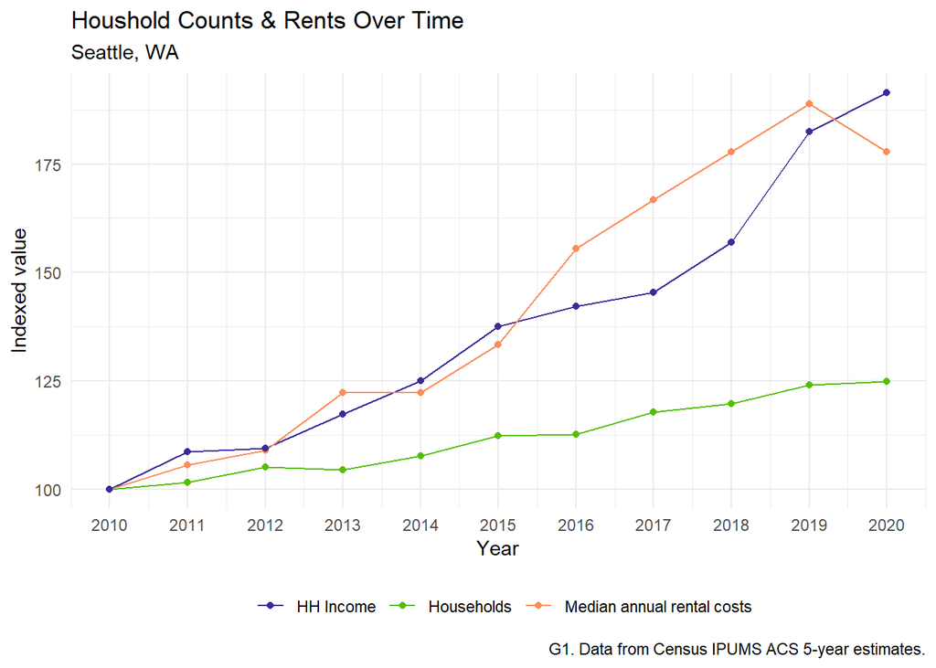

## Rents track incomes more closely than owner costs

Due to differences in the markets for properties-to-own-and-occupy and properties-to-rent-and-occupy, rental costs tend to track the incomes of renters more closely than owner costs do the incomes of owners. For example, rents may increase annually, at the end of each rental period, whereas owner costs for properties with fixed-rate mortgages typically only increase when the property transacts, or when the property owner refinances. Occupants of property-to-own, then, may be less exposed to annual changes in the housing market, and this may be one reason policymakers may be more concerned about apartment rents than owner costs.

Nevertheless, it is important to remember that properties-to-own and properties-to-rent are substitutes in consumption. Increasing rents will also increase the purchase price of homes, and high purchase prices for properties-to-own-and-occupy will put upward pressure on rents. To see why, consider a mid-career migrant to Seattle. That person will consider both renting and purchasing property. They will weight many different factors, among which are the relative costs of owning a property versus renting one. If rents are significantly lower than ownership costs, they may choose to rent rather than own. In the aggregate, higher ownership costs will increase the rents landlords may charge tenants, as newcomers bid up rent prices in desirable areas. In short, the single-family and residential condominium housing markets have a strong impact on the rental housing market, and vice versa.

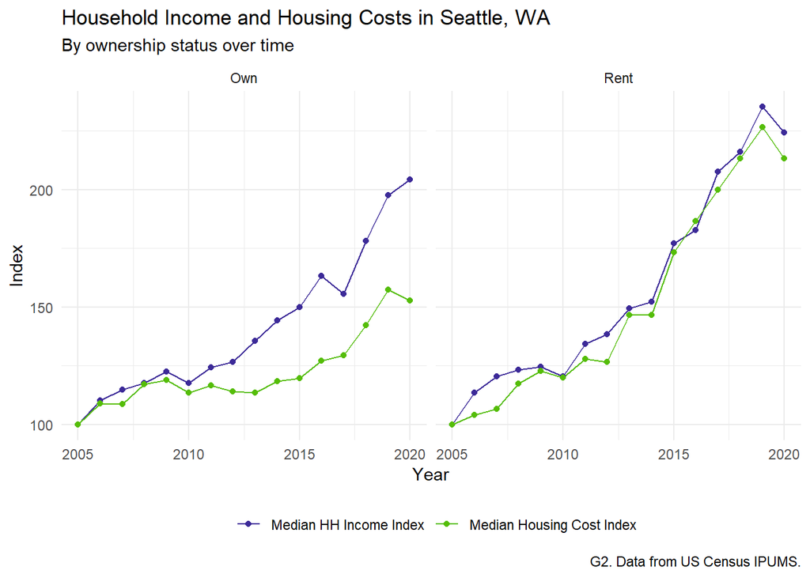

# Trends in Seattle housing composition

This section describes the current state of and changes over time in the composition of the rental housing stock in Seattle. Following the categorization schema used by the US Census Bureau, we focus on the number of units in five different building size classes, from single-family to large buildings with more than 50 units. For this analysis, we rely on several data sets. Each sub-section highlights results from a specific data set. Overall, we see little evidence that Seattle is losing units within any category of building size. Most new units are being built in large buildings. The share of housing units in smaller buildings declined over time, since the number of units in smaller buildings remained constant as the total number of units increased.

## American Community Survey data

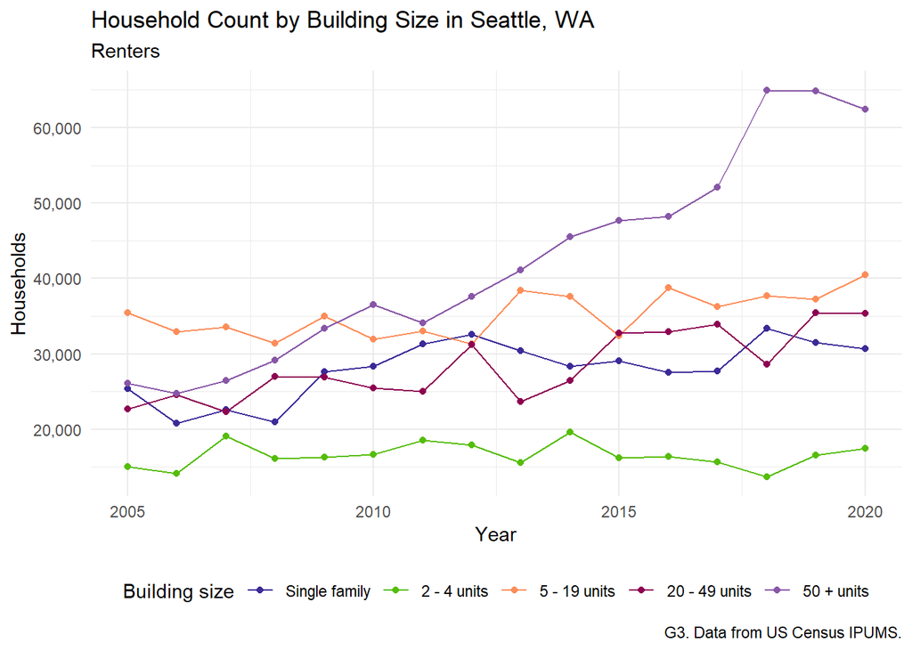

IPUMS data only captures net households over time for the entire City of Seattle. We need to use different data sources for a more granular view.

## Seattle construction permit data

The City of Seattle’s Office of Planning and Community Development (OPCD) tracks and reports building permit data [in a well-built online dashboard](https://experience.arcgis.com/experience/53932efb64da40f6914c37e086b7dcbb). Since building permits are an integral part of multiple highly visible administrative processes, we believe the permit data is reliable and mostly accurate. However, since building permits are not designed to track housing stock over time, they do not capture all the information one might want for the purpose of this analysis.

The graph below shows net changes in units categorized by building size. The trends shown are very consistent with those in the ACS data shown in the prior section.

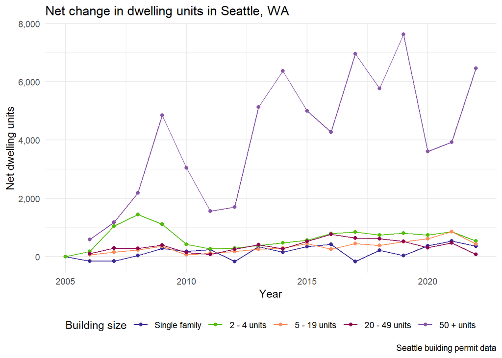

Seattle’s permit data also allows us to track gross additions and demolitions separately. The graph below shows these figures over the entire sixteen-year period, grouped by building size. Very few permits for demolitions of multi-unit buildings in Seattle (so few that they are not visible with the scale of the y axis on the chart below). Tabular data can be found on GitHub.

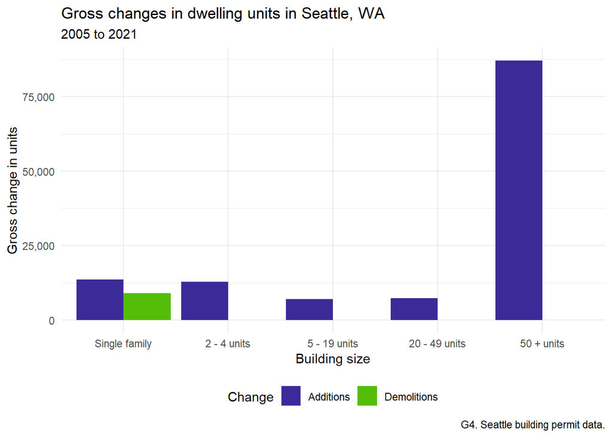

## King County tax roll

The King County tax roll might seem to be a data set that could inform us about changes in Seattle real estate. The tax roll records individual tax parcels, the physical attributes of the buildings they contain, and their user categorization. One might think that comparing tax rolls across years should give a reasonably clear picture of the changes in the housing stock in Seattle. One who thought so would be wrong.

Unfortunately, tax roll data is not a particularly helpful resource to investigate changes in housing composition over time in Seattle. This is so for two reasons. First, the data is very difficult to access. The King County Assessor’s Office (KCAO) publishes the tax roll for the current year in various files [on their website](https://info.kingcounty.gov/assessor/datadownload/default.aspx). Every year, the KCAO removes the previous years’ files and replaces them with the current years’ files. These historical files become unavailable to the public; the KCAO denied our open records request for previous years’ files.

Assessment data may be purchased through third-party vendors for most jurisdictions in the US. We purchased historical data for Seattle for years 2017 to 2021 from a major vendor. This data, however, did not contain reliable parcel classifiers and residential unit counts. This is likely due to the vendor’s process of translating the KCAO’s data into a general schema that can be applied nationwide. Our analysis of this third-party data found that it was not useful for the purposes of this report.

As a general practice, the OPCD downloads and stores the KCAO’s parcel data before it is replaced each year. They transform that data for their purposes and store it. They shared that data with us. Unfortunately, due to the way in which the data was transformed, it was not useful for this portion of the analysis.

In sum, this analysis was hampered by the lack of direct access to the KCAO’s current and historic data files. For this reason, we recommend the KCAO pursue a higher level of data transparency.

Other than the difficulty of accessing the KCAO’s data, the KCAO’s data model also makes it difficult to use for this type of analysis. A data model is simply the way the data is organized in a database. Data models critically impact how data may be easily used. In most Assessment offices, real estate *parcels* form the basis of data models. It is important to understand that a parcel does *not* represent a building, a plot of land, or any other real estate asset. Parcels are units of account that designate property tax liability. A parcel may designate any part of one or more real property assets, including land, buildings, air rights, units within buildings, parking spots, or leaseholds. In short, using parcels to make inferences about buildings is fraught with risk of error. Parcels are not a good unit of observation for buildings and dwelling units.

# Trends in Seattle property ownership

This section describes the current state and changes over time in the ownership of rental housing. As part of normal business operations, TrueRoll identifies and stores parcel ownership records. Based on owners’ names, owners are categorized as companies or individuals. Owners are grouped by their mailing address such that multiple people or companies with a common mailing address are treated as a single ownership entity. Doing this allows us to infer common ownership across different LLCs. For example, one property owner may have multiple LLCs, one for each of their properties. But since, for example, the owners of `123 Main St.` and `456 This Wy.` both share a common mailing address, they are treated as a single ownership entity. Owners are categorized as companies based on whether owner names contained company identifiers, “LLC” for example.

As mentioned above, OPCD shared historical parcel data with TrueRoll for this study. We joined TrueRoll ownership records to the tax roll for each year. This allowed us to track owners and their portfolios over time. It also allowed us to characterize owners based on the number of parcels, buildings, and units they own.

Part of the scope of this study involved defining “small landlord”. The table below shows the categorization schema we used to define different types of property owners. This categorization schema is informed by the Urban Institute’s work over the past few years on “Mom-and-pop” landlords in Minneapolis, MN, and other cities. See the links at the end of this document for references. While we cannot follow their definition exactly due to differences in the data that is available to us, we can follow it in general.

In the table below, owners must meet all of the criteria in the first two categories to be categorized as either a “Mom-and-pop” or “Small property manager” owner. The buildings field was not always populated because of the way the King County Assessor tracks buildings data. Owners with null building counts that met the other criteria for “Mom-and-pop” and “Small” landlords were included in those categories. Owners meeting any of the criteria in the next two rows are categorized as one of “Midsized” or “Large” property manager categories. Owners that meet criteria in both the “Midsized” and “Large” property manager categories are categorized as “Large property managers.” For example, properties owners with 20 parcels and 51 units, and 22 parcels and 49 units are both classified as large property managers.

Finally, we excluded the owners of condominiums from this part of our analysis. We did this for two reasons. First, the historical parcel data we were using from OPCD made it difficult to distinguish individual condominium units from condominium buildings, and classify units into the schema below. Second, a condominium unit owner is qualitatively different from the owner of a single-family parcel or a multi-family apartment. Including condominium owners in the sample added unnecessary complexity to the analysis, which is focused on the owners of single- and multi-family buildings.

Table 5.1: Category criteria for owner type.

| Owner type | Parcels owned | Buildings owned | Units owned | Company ownership |
| --- | --- | --- | --- | --- |
| Mom-and-pop | <=3 | <=6 or null | <=10 | No |
| Small property manager | <=3 | <=6 or null | <=10 | Yes |
| Midsized property manager | 4 <= n <= 20 | >6 | 11 <- n <= 50 | Yes or No |
| Large property manager | > 20 | > 6 | > 50 | Yes or No |

The table below shows owner and unit counts for 2021 that use this categorization. The total number of units in our ownership data in 2020 was 190,393. According to the IPUMS ACS data, the number of renting households was 186,406. The close agreement in unit counts gives us some confidence that our ownership data is reasonably complete.

Table 5.2: Owner and unit counts by owner type.

| Year | Owner type | Owners | Units |
| --- | --- | --- | --- |
| 2015 | Large property manager | 333 | 57,307 |
| 2015 | Midsized property manager | 3,093 | 63,270 |
| 2015 | Mom-and-pop | 24,768 | 35,063 |
| 2015 | Small property manager | 1,360 | 4,259 |
| 2021 | Large property manager | 344 | 77,945 |
| 2021 | Midsized property manager | 3,120 | 76,298 |
| 2021 | Mom-and-pop | 24,618 | 33,909 |
| 2021 | Small property manager | 2,035 | 5,984 |

## Changes in unit and owner counts by owner type over time

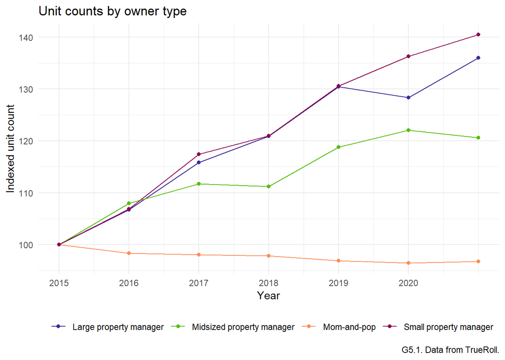

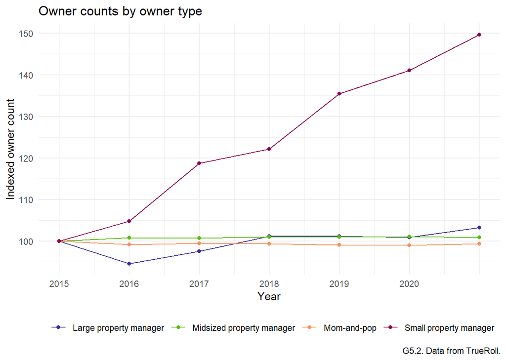

# Trends in Seattle apartment rents

This section describes the current rents charged in different types of rental properties. We used TrueRoll’s rental data for this section of the analysis. As part of normal business operations, TrueRoll maintains the following data: rental listings posted on public websites, property records from the Assessors’ office, and ownership records for each parcel. Combining this data allows TrueRoll to categorize parcels and rental listings based on owner and property characteristics. TrueRoll observed 834,672 rental listings from 2010 to 2022. TrueRoll began actively monitoring Seattle rental sites in late 2019, so most rental data comes from after that time. Removing listings pre-2019 leaves us with 801,457 listings.

There is not a one-to-one relationship between apartment listings and vacant apartment units. We believe some apartment owners create one listing per unit. Some create multiple listings per unit over time since re-posting can increase a listing’s visibility. Some apartment owners may create one listing for many units. For example, a large building may create one listing for each unit type by beds and baths. Small apartment owners may be less likely to post rental listings on public websites than others, preferring physical advertising and word of mouth.

We did not want some properties in our sample to be over- or under- represented simply due to differences in listing strategies. However, we had limited time to devise a reasonable way to address potential bias in our rental sample. In constructing the final rental data sample, we aggregated listings by apartment types (beds & baths) for each parcel, in each year. These aggregations result in 32,051 records, with each record representing the average rental price for an x bed, y bath apartment at a given parcel in a given year. The table below shows a stylized data model.

Table 6: Stylized rental data model.

| Parcel | Bedrooms | Units | Listings | Baths |
| --- | --- | --- | --- | --- |
| A | 1 | 20 | 200 | 1.75 |
| A | 2 | 10 | 100 | 2.25 |
| A | 3 | 30 | 400 | 2.50 |
| B | 1 | 30 | 400 | 2.50 |

In the stylized example, parcel A has three unit types: 1,2, & 3 bedroom apartments. We observed 200 listings of 20 one-bedroom apartment units in parcel A. The average bathroom count was 1.75 for these one-bedroom apartments. Our final rental sample includes 31,968 observations of units with listings, of which 11,501 units have complete information about the unit and the building that contains the unit.

The rental data has good coverage overall [(See table 15)](https://github.com/trueroll/seattle_rental_study/tree/main/outputs/T15.csv), but the coverage rate is much lower for smaller apartment buildings. This is a strong indicator of *selection bias*; some mom-and-pop property owners are listing vacant units on the websites TrueRoll monitors, while others are not. If these two groups charge equivalent rents, this isn’t a barrier to the analysis. However, if rents are correlated with the decision to list an apartment online, we have a selection bias issue. For example, suppose that owners of apartments that charge lower rents are much less likely to list vacant units online, instead preferring physical signage and network referrals. In such a case, the average observed list rent online would be inflated. This may be the case with the rental sample we use in this section.

## Rents by building size

While single-family homes command a rent premium on average, rents do not vary much across apartment buildings of different sizes. In the graph below, we have combined IPUMS data with TrueRoll’s rental data, described in depth below. We can see that the rental data skews high, again reinforcing our suspicion that it suffers from selection bias.

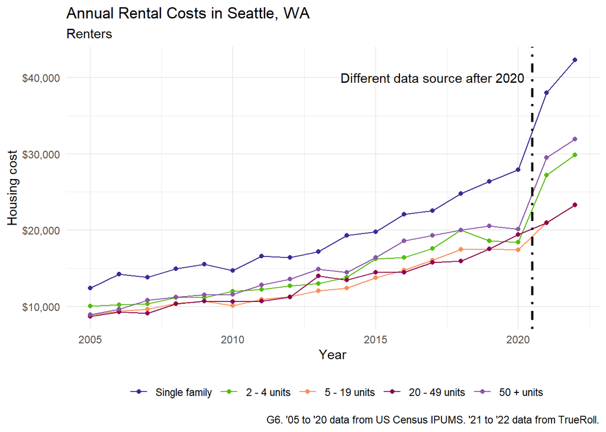

The graph below shows median annual rents by building size and bedroom count. While two building size categories - single-family and 50+ unit buildings - command higher rents, the other building size classes do not appear to differ in terms of rent across bedroom counts

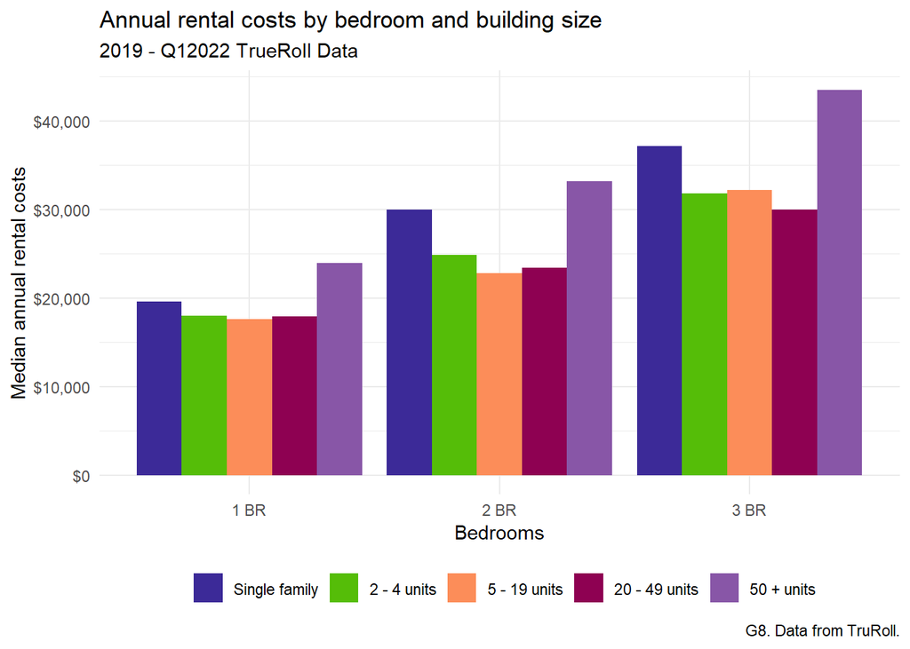

### Linear regression

Multiple factors impact apartment rents, including the attributes of the units, the buildings that contain them, and the neighborhoods in which those buildings are located. Property owner attributes may also impact rents in those buildings. Owners who live in one of the units in their building may be more likely to exchange lower rents for non-financial concessions, like lower levels of unit or building maintenance. Owners that have no personal interaction with their tenants may include risk premiums in their rents, while owners that interact with their tenants may not need to do so. Owners with small portfolios may be concerned about damage to their personal and professional reputations that could be caused by increasing rent or evicting tenants.

We test each hypothesis using [linear regression](https://en.wikipedia.org/wiki/Ordinary_least_squares). The table below shows the results of a regression of annual rental cost on building size. A linear regression is a way to calculate both unconditional and conditional averages. In the table below, columns (1) and (2) show unconditional average annual rents by building size. Unconditional averages, or ‘simple’ averages, can just as easily be displayed in a table. The advantage of using a regression to calculate averages is that we also see each average’s [95% confidence interval](https://en.wikipedia.org/wiki/Confidence_interval) in parentheses.

The confidence interval helps us see whether averages are statistically different from each other. For example, in (2) in the table below, single family properties rent for about $50,250 per year, on average, while units in small apartment buildings (2-4 units) rent for only $23,534 on average. We can say that the difference in these averages is highly statistically significant because each estimate is outside the others’ confidence interval. Moreover, the difference in the relative size of the intervals for the average for Single family and small apartment buildings tells us that there is much more variance in rents for Single family properties than there is in small multi-family properties.

Regressions also can be used to calculate *conditional* averages. As we noted above, many factors impact rents. Including additional “covariates” in a regression helps us see how these additional variables may impact the relationship between annual rents and the variables we are interested in studying. In (3) below, we show average rents by building size *conditional* on the year the apartment was listed, bedroom and bathroom counts, the census tract that contains the building, and the building’s age. Observe that the standard errors on the conditional averages are much larger than on the unconditional averages. They are no longer statistically different from each other. Additionally, the estimated coefficients are now negative. Negative coefficients in this case do not have a clear intuitive interpretation. Negative coefficients may arise from regressions with a large number of correlated predictors. Both the large confidence interval and the negative coefficients show us that the differences in average rents across building sizes are due mostly to differences in the covariates included in (3).

It is important to note that these regressions are not identifying a causal relationship. We simply show that building size is highly correlated with other variables that also strongly impact rent, making it very difficult to say why rents are different in buildings of different sizes. We omitted the regression statistics from the tables as irrelevant to the current analysis. Readers should note that the estimated averages using IPUMS ACS data are lower than those estimated using TrueRoll rental data. This is partly because TrueRoll is observing apartment rental listings, while the ACS is capturing contract rent for current occupants. Also, TrueRoll’s rental data may be biased upwards, as discussed.

**Rents and building size**

|  | *Dependent variable:* |  |  |
| --- | --- | --- | --- |
|  | `Annnual rental costs` |  |  |
|  | IPUMS ACS | TR Rental Data | TR Rental Data |
|  | (1) | (2) | (3) |
| Single-family | 19,165 | 50,250 | -65,782 |
|  | (18,898, 19,432) | (42,606, 57,894) | (-76,136, -55,428) |
| 2 - 4 units | 13,933 | 23,534 | -71,540 |
|  | (13,558, 14,307) | (23,000, 24,067) | (-79,930, -63,150) |
| 5 - 19 units | 12,685 | 21,359 | -72,736 |
|  | (12,429, 12,940) | (21,152, 21,566) | (-81,167, -64,305) |
| 20 - 49 units | 12,955 | 21,195 | -72,657 |
|  | (12,668, 13,242) | (20,887, 21,503) | (-81,133, -64,182) |
| 50+ units | 15,517 | 29,170 | -68,698 |
|  | (15,273, 15,761) | (28,879, 29,461) | (-77,295, -60,101) |
| Year | No | No | Yes |
| Bedrooms | No | No | Yes |
| Bathrooms | No | No | Yes |
| Census tract | No | No | Yes |
| Building age | No | No | Yes |

## Rents charged by ‘Mom-and-pop’ landlords

The table below shows two regressions. Regression (1) shows unconditional average rents by owner type. On average, unconditional average annual rents in buildings owned by a ‘Large property manager’ are about $3,000 more than those in buildings owned by a ‘Mom-and-pop’ landlords. All unconditional averages are calculated with a very small margin of error. There is not a statistically significant difference between Mom-and-pop landlords and Small and Medium sized landlords.

It may be the case that the apartments listed in buildings owned by different types of landlords are systematically different. For example, if Mom-and-pop landlords own structures that are relatively older, or located in less desirable areas, their rents might be lower. Regression (2) shows average annual rents *conditional* on the number of bedrooms and bathrooms, the census tract that contains the building, and the building’s size and age. Whereas unconditional average annual rents (1) showed a statistically significant difference across owner types, conditional average annual rents are not statistically different for any of the owner types as we have defined them. This indicates that the differences in list rents across ownership types are explained by differences in the attributes of the units, buildings, and their locations.

**Rents and owner type**

|  | *Dependent variable:* |  |
| --- | --- | --- |
|  | `Annnual rental costs` |  |
|  | (1) | (2) |
| Large property manager | 25,248 | -2,101,173 |
|  | (24,971, 25,526) | (-2,307,071, -1,895,276) |
| Midsized property manager | 22,565 | -2,101,528 |
|  | (22,360, 22,770) | (-2,307,424, -1,895,631) |
| Small property manager | 22,591 | -2,101,093 |
|  | (22,020, 23,161) | (-2,307,000, -1,895,186) |
| Mom-and-pop | 22,225 | -2,101,691 |
|  | (21,608, 22,842) | (-2,307,596, -1,895,785) |
| Year | No | Yes |
| Bedrooms | No | Yes |
| Bathrooms | No | Yes |
| Census tract | No | Yes |
| Building size | No | Yes |
| Building age | No | Yes |

The graph below shows the same data plotted as a bar chart without covariates.

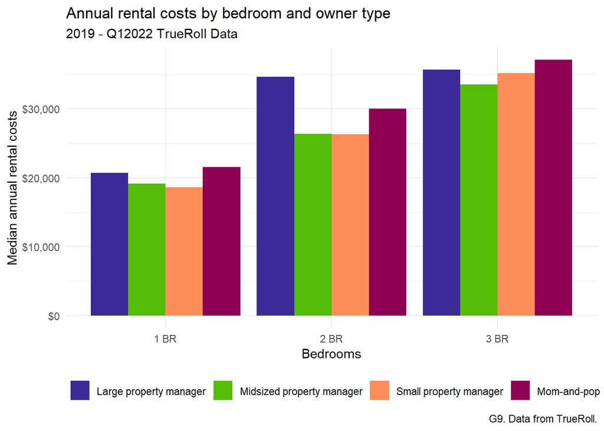

## Rents and owner location

As noted above, TrueRoll imputed owners’ locations based on the mailing addresses for each property’s tax bill. On average, Seattle property owners who live anywhere in Washington state charge slightly lower rents than owners who live in the Seattle metropolitan area. Unconditionally, owners who live outside Washington state charge $7,700 per year more than owners that live in Washington outside the Seattle metropolitan area. As with the owner types analysis above, differences across owner locations become insignificant after accounting for unit and building attributes and census block.

**Rents and owner location**

[output not shown]

## Rents by owner-occupancy status

**Rents and owner occupancy**

|  | *Dependent variable:* |  |
| --- | --- | --- |
|  | `Annnual rental costs` |  |
|  | (1) | (2) |
| Owner occupied | 23,371 | -65,869 |
|  | (23,215, 23,526) | (-76,230, -55,507) |
| Not owner occupied | 21,205 | -65,321 |
|  | (17,484, 24,926) | (-75,879, -54,763) |
| Year | No | Yes |
| Bedrooms | No | Yes |
| Bathrooms | No | Yes |
| Census tract | No | Yes |
| Building size | No | Yes |
| Building age | No | Yes |

# Recommendations

In this section we make recommendations to improve Seattle’s ability to track rental housing and rents. These recommendations pertain only to improving visibility of Seattle’s rental market to policymakers. We do not make recommendations relating to housing or development policy in Seattle. We are also agnostic about the mechanism by which our recommendations are acted on, whether directly by a unit of local government, or by a subcontracted company or academic team, or some combination thereof.

## Create a complete, integrated real property database

A central challenge to this type of analysis is simply determining what real property exists in Seattle in each year. There does not exist a complete and thorough record of each rentable residential space in Seattle. The City of Seattle should coordinate with King County, and any other pertinent agencies, to create a complete, accurate, detailed, digital record of every unit of real property in Seattle and King County. This record should uniquely identify real estate assets and objects including: buildings, units, plots, parcels, permits, and many other units of real property. Each unit should be stored in a dedicated relational database with clear relationships to every other unit.

Building such a database will require substantial technical competency, as well as coordination across agencies in different units of government, and, perhaps most importantly, significant buy-in from elected officials and other policymakers. If successful, such a project would result in a highly valuable public asset that will serve Seattle residents for generations.

### Coordination across agencies

In preparing this report, TrueRoll coordinated with at least three agencies in Seattle and King County. The City of Seattle’s Department of Constructions and Inspections was our primary contact. The City of Seattle’s Office of Planning and Community Development assisted in the analysis by providing historical King County tax records and curated building permits. And we also used the King County Assessor’s Office’s public records posted on their website.

It is common for multiple agencies to each hold a part of the puzzle regarding real property data. Each agency stores and curates real property data for its own uses, and there typically is not a coordinating agent across the entire data ecosystem. This is the case even in Counties and Cities that have Chief Data Officers. This fractured approach to real property data makes it very difficult to get a complete picture of the real property in an area.

#### Establish a Chief Data Officer role

Data is a public asset, and there should be a chief executive mandated with the development of these assets for the City of Seattle. A well-supported Chief Data Officer can work across agency silos to develop a comprehensive data governance strategy that serves all agencies in a comprehensive manner. Without such a role, it will be difficult for the City of Seattle and King County to coordinate effectively to collect and manage detailed real estate data.

### Transparency makes government more efficient and effective

Agencies that collect and store real property data should make that data available to the public, and therefore each other, at the most granular level. Transparency improves the effectiveness of every agency that uses real property data. Currently, different agencies engage in redundant retrieval and storage of each others’ data. This creates wasteful duplication and makes it very difficult to maintain data integrity across disparate agencies. By establishing a transparent, accessible, comprehensive database, the City of Seattle and King County can eliminate redundancy and enable agencies to do their work better and faster. For example, the Cook County Assessor’s Office has released [the entire parcel record from 1999 to present](https://datacatalog.cookcountyil.gov/Property-Taxation/Assessor-Parcel-Universe/tx2p-k2g9), and their [data release notes](https://datacatalog.cookcountyil.gov/stories/s/p2kt-hk36) have been [viewed more than 40,000](https://datacatalog.cookcountyil.gov/browse?q=Assessor&sortBy=relevance) times since it was released two years ago.

### Sample a subset of market data and model rents

The rental market is fairly efficient. As a result, there is much less heterogeneity across rental units than across single-family homes. Most variation in rental prices is due to a very limited set of explanatory variables: location, bedroom and bathroom count, and building amenities, which usually correlate highly with the building’s effective age. A random sample of 10% of rental units in Seattle, stratified by geography and building class, will likely be sufficient to develop a highly accurate understanding of rental trends in the city.

The data collected by a random survey of existing tenants and landlords will produce more accurate data than can currently be purchased by vendors. First, data vendors have a similar smapling problem to TrueRoll’s rental data, namely, that small properties are underrepresented in their sample. This is so because large vendors cater to property brokers and investors, who are typically uninterested in properties that yield lower rents, or have higher maintenance costs. A well-designed sample could complement the limited data the City has available for smaller rental properties. This could include special sampling protocols designed to collect representative data for properties owned by mom-and-pop and other small landlords who are generally less likely to be captured by large data vendors.

The way this data is collected will be extremely consequential to its usefulness. [Skeuomorphic](https://en.wikipedia.org/wiki/Skeuomorph) web forms should be avoided. Instead, a step-by-step interactive web application should be used to guide users through a submission process that populates a well-defined data model. The Cook County, IL Assessor’s Office recently launched such a platform called the Real Property Income and Expense Online Form. A detailed description of that platform’s design [can be found online](https://gitlab.com/ccao-data-science---modeling/documentation/wiki_content/-/blob/master/RPIE/RPIE%20Overview.md).

Additionally, data collection should not proceed before a thorough design period that involves multiple parties of various disciplines. Survey statisticians and data scientists should be consulted to determine which sample strata need to be targeted, and to build the models that will leverage the collected data. Public administration specialists should help craft the survey design and communications strategy. Project administrators should ensure organisation in the execution of the survey. Technologists should be consulted to build the right tools to collect and store the data. Collecting data of this type and magnitude requires significant coordination, which is why we recommend the formation of a consortium below.

Combined with a well-conceived real property database, randomly sampled rental data can be used to estimate rents across the city with a high degree of accuracy. Automated valuation models are commonly used in the property tax assessment industry to predict the value of non-rental residential property in a jurisdiction. The same approach may be used to model apartment rents. This reduces the amount of rental data that must be collected by a large margin while still allowing a clear picture of rental rates in the city of Seattle.

#### Compensate landlords for their data

Data is valuable. Laws that compel people to submit data often result in low compliance rates and low quality data. We suggest that the city of Seattle pay landowners to submit their data. Compensation can be based on our prior knowledge of landlord’s portfolio sizes. Coupled with our recommendation above to sample only a fraction of the total rental units, this recommended payment would result in a modest annual outlay of funds.

## Continuous investment in capacity

This study is the second of such kind since 2016. In [their 2018 study](https://www.seattle.gov/Documents/Departments/CityAuditor/auditreports/UWSRHSFINAL.pdf), Professor Crowder describes formation of a University of Washington (UW) research consortium including Center for Studies in Demography and Ecology (CSDE), and Runstad Department of Real Estate. In a May 5, 2022, letter to the Council’s Finance and Housing Committee, Dr. Young of the Center for Real Estate Research at the Runstad Department of Real Estate suggested that the Center could form a working group involving private sector organizations, community leaders and City departments to identify strategies for filling rental housing market data gaps. (See [attachment to Mayor’s letter](http://seattle.legistar.com/View.ashx?M=F&ID=11027351&GUID=646B0932-5E1D-4859-8271-5DC45EF60CF1) on Council Bill 120325.) We reiterate this recommendation.

## Modify rental registry data model and collection method

The City of Seattle’s Department of Constructions and Inspections maintains a registry of rental properties. We did not, however, find Seattle’s rental registry data useful for this analysis. This was so for a few reasons. First, it was not possible to identify when registered units entered and exited the registry using the data. Second, only one parcel number is attached to each registry. Multi-family buildings often occupy more than one parcel, making it more difficult to identify which parcels had not been registered. Finally, the registry does not record any attributes about the units registered. Together, these facts made it impossible to use the data for time trend analysis. We recommend retooling the rental registry data storage and collection model to make the data more usable for various analyses.

Though it was outside the scope of this project, TrueRoll compared the list of active registered rental properties on Seattle’s rental registry to rental listings observed in 2021 and Q1 2022. We found 3,964 parcels that were associated with a rental listing in TrueRoll’s rental data, but were not listed as active on Seattle’s rental registry. Seattle’s rental registry only connects one address with one parcel number. It is very common for one building to have multiple addresses and parcels, so our count of unregistered parcels is likely higher than the actual figure. Creating a unified real property data model across the various agencies as mentioned above will help enhance the registry’s value to Seattle.

# Additional resources

Below are some articles, data, and software that supported this analysis.

Steven Ruggles, Sarah Flood, Ronald Goeken, Megan Schouweiler and Matthew Sobek. (IPUMS USA: Version 12.0 [dataset])[https://doi.org/10.18128/D010.V12.0]. Minneapolis, MN: IPUMS, 2022.

Hlavac, Marek (2022). stargazer: Well-Formatted Regression and Summary Statistics Tables. R package version 5.2.3. https://CRAN.R-project.org/package=stargazer

“2021 State of Rental Housing in Cook County.” *Institute for Housing Studies at DePaul University*. https://www.housingstudies.org/releases/state-rental-2021/.

Choi, Jung Hyun and Caitlin Young. “[Owners and Renters of 6.2 Million Units in Small Buildings Are Particularly Vulnerable during the Pandemic.](https://www.urban.org/urban-wire/owners-and-renters-62-million-units-small-buildings-are-particularly-vulnerable-during-pandemic)” *Urband Labs.* August 10th, 2020.

Elora Lee Raymond, Richard Duckworth, Benjamin Miller, Michael Lucas, and Shiraj Pokharel. “[From Foreclosure to Eviction: Housing Insecurity in Corporate-Owned Single-Family Rentals.](https://www.huduser.gov/portal/periodicals/cityscpe/vol20num3/article9.html)” *Cityscape.* V.2, N. 3.

Freemark, Yonah, Eleanor Noble, and Yipeng Su. “[Who owns the twin cities?](https://www.urban.org/sites/default/files/publication/104355/who-owns-the-twin-cities.pdf)” *Urban Institute*. June 2021.

Goodman, Laurie, Jung Hyun Choi, Daniel Pang. “[Mom-and-Pop Landlords Are Raising Rents, Albeit Less Than Market Rates, Leaving Renters with Few Places to Turn.](https://www.urban.org/urban-wire/mom-and-pop-landlords-are-raising-rents-albeit-less-market-rates-leaving-renters-few?utm_medium=linkedin&utm_source=urban_social)” *Urban Institute.* October 2022.

Crowder, Kyle. “[Seattle Rental Housing Study.](https://www.seattle.gov/Documents/Departments/CityAuditor/auditreports/UWSRHSFINAL.pdf)” *University of Washington,* Center for Studies in Demography and Ecology. June 2018.